# MUSA 508, Lab 4 - Spatial Machine Learning Pt. 1

Harris, Fichman, and Steif - 2022/23

# MUSA 508, Lab 4 - Spatial Machine Learning Pt. 1

The learning objectives of this lab are:

- Review Topics: loading data, {dplyr}, mapping and plotting with {ggplot2}
- New: Understanding how we created spatial indicators with K-Nearest Neighbor and the `nn_function()` function
- Simple correlation and the Pearson’s r - Correlation Coefficient
- Linear Regression model goodness-of-fit and R2 - Coefficient of Determination

The in-class exercise at the end encourages students to modify the existing code to create a different regression and interpret it. Finally, there is a prompt to create a new feature and add it to the regression.

## Data Wrangling

See if you can change the chunk options to get rid of the text outputs

```r
nhoods <- st_read("https://raw.githubusercontent.com/mafichman/musa_5080_2023/main/Week_4/neighborhoods/bost_nhoods.geojson") %>%
  st_transform('ESRI:102286')
boston <-
  read.csv(file.path(root.dir,"/Chapter3_4/bostonHousePriceData_clean.csv"))

boston.sf <-
  boston %>%
  st_as_sf(coords = c("Longitude", "Latitude"), crs = 4326, agr = "constant") %>%
  st_transform('ESRI:102286')


bostonCrimes <- read.csv(file.path(root.dir,"/Chapter3_4/bostonCrimes.csv"))
```

### Exploratory data analysis

```r
# finding counts by group
bostonCrimes %>%
group_by(OFFENSE_CODE_GROUP) %>%
  summarize(count = n()) %>%
  arrange(-count) %>% top_n(10) %>%
  kable() %>%
  kable_styling()
```

| OFFENSE_CODE_GROUP | count |
| --- | --- |
| Motor Vehicle Accident Response | 23717 |
| Larceny | 16869 |
| Drug Violation | 15815 |
| Other | 12797 |
| Medical Assistance | 12626 |
| Investigate Person | 10266 |
| Simple Assault | 9932 |
| Vandalism | 8300 |
| Larceny From Motor Vehicle | 8219 |
| Verbal Disputes | 7721 |

### Mapping

See if you can alter the size of the image output. Search for adjusting figure height and width for a rmarkdown block

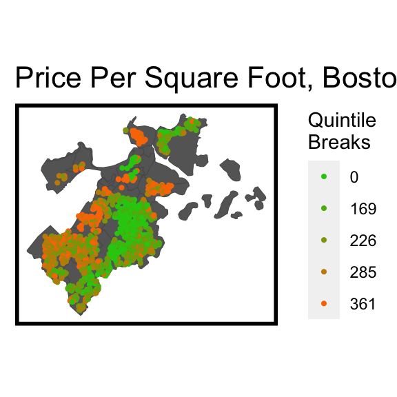

```r
# ggplot, reorder

# Mapping data
ggplot() +
  geom_sf(data = nhoods, fill = "grey40") +
  geom_sf(data = boston.sf, aes(colour = q5(PricePerSq)),
          show.legend = "point", size = .75) +
  scale_colour_manual(values = palette5,
                   labels=qBr(boston,"PricePerSq"),
                   name="Quintile\nBreaks") +
  labs(title="Price Per Square Foot, Boston") +
  mapTheme()
```

### Cleaning Crime Data

Let’s filter for only a particular type of offense, Aggravated Assault.

We turn it from data frame into sf using `st_as_sf` and then keep only distinct observations.

Why are we using a filter for `Lat > -1`?

```r
bostonCrimes.sf <-
  bostonCrimes %>%
    filter(OFFENSE_CODE_GROUP == "Aggravated Assault",
           Lat > -1) %>%       # this is like putting NA, placeholder for a value that is unknown
    dplyr::select(Lat, Long) %>%
    na.omit() %>%
    st_as_sf(coords = c("Long", "Lat"), crs = "EPSG:4326") %>%
    st_transform('ESRI:102286') %>%
    distinct()
```

### Create Nearest Spatial Features

This is where we do two important things:

- aggregate values within a buffer, and
- create `nearest neighbor` features.

These are primary tools we use to add the local spatial signal to each of the points/rows/observations we are modeling.

#### k nearest neighbor (knn)

The second block of code is using knn for averaging or summing values of a set number of (referred to as `k`) the nearest observations to each observation; it’s *nearest neighbors*. With this, the model can understand the magnitude of values that are *near* each point. This adds a spatial signal to the model.

The number `k` in the `nn_function()` function is the number of neighbors to to values from that are then averaged. Different types of crime (or anything else you measure) will require different values of `k`. *You will have to think about this!*. What could be the importance of `k` when you are making knn features for a violent crime versus and nuisance crime?

```r
# Counts of crime per buffer of house sale
boston.sf$crimes.Buffer <- boston.sf %>%
    st_buffer(660) %>%
    aggregate(mutate(bostonCrimes.sf, counter = 1),., sum) %>%  # chotto wakannnai, there's a section on this in the book
    pull(counter)

# Nearest Neighbor Feature
boston.sf <-
  boston.sf %>%
    mutate(
      crime_nn1 = nn_function(st_coordinates(boston.sf),
                              st_coordinates(bostonCrimes.sf), k = 1),

      crime_nn2 = nn_function(st_coordinates(boston.sf),
                              st_coordinates(bostonCrimes.sf), k = 2),

      crime_nn3 = nn_function(st_coordinates(boston.sf),
                              st_coordinates(bostonCrimes.sf), k = 3),

      crime_nn4 = nn_function(st_coordinates(boston.sf),
                              st_coordinates(bostonCrimes.sf), k = 4),

      crime_nn5 = nn_function(st_coordinates(boston.sf),
                              st_coordinates(bostonCrimes.sf), k = 5))

# comp : feature that describes predicted value of a home based on prices of nearest houses that were sold
# might be important to compare after filter for other features of the house (like number of bedrooms)
# square footage is a great proxy
# how to choose the best k? it depends lol mostly depends on magnitude of the target,
```

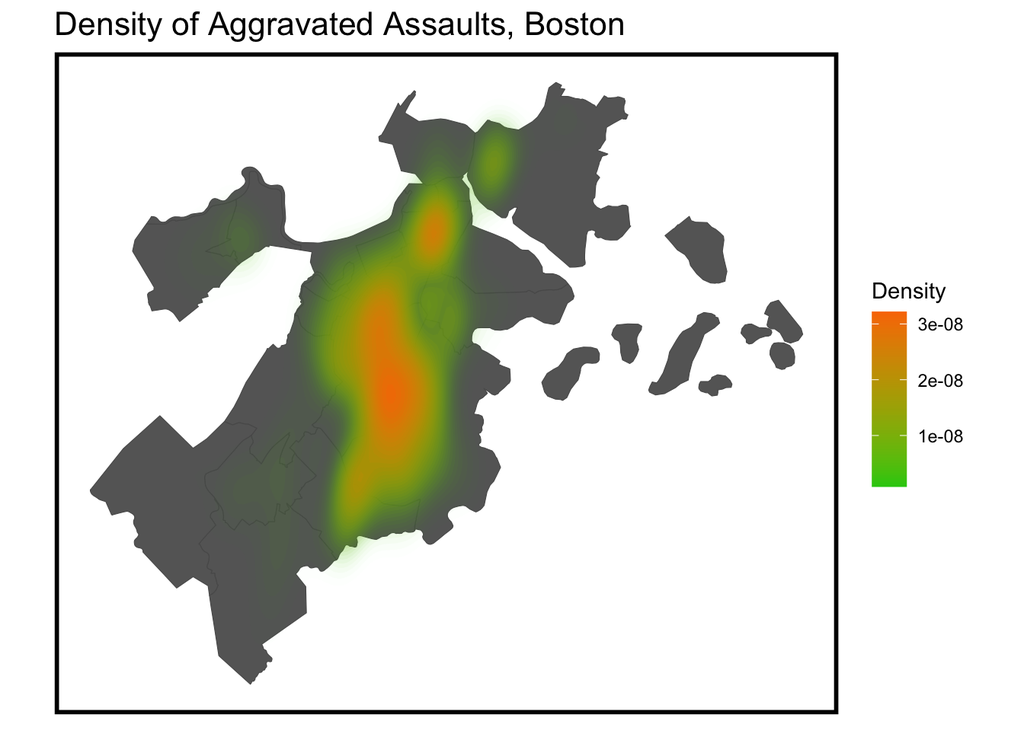

```r
## Plot assault density
ggplot() + geom_sf(data = nhoods, fill = "grey40") +
  stat_density2d(data = data.frame(st_coordinates(bostonCrimes.sf)),
                 aes(X, Y, fill = ..level.., alpha = ..level..),
                 size = 0.01, bins = 40, geom = 'polygon') +
  scale_fill_gradient(low = "#25CB10", high = "#FA7800", name = "Density") +
  scale_alpha(range = c(0.00, 0.35), guide = "none") + # feathering as intensity gets lower
  labs(title = "Density of Aggravated Assaults, Boston") +
  mapTheme()
```

## Analyzing associations

Run these code blocks… Notice the use of `st_drop_geometry()`, this is the correct way to go from a `sf` spatial dataframe to a regular dataframe with no spatial component.

Can somebody walk me through what they do?

Can you give me a one-sentence description of what the takeaway is?

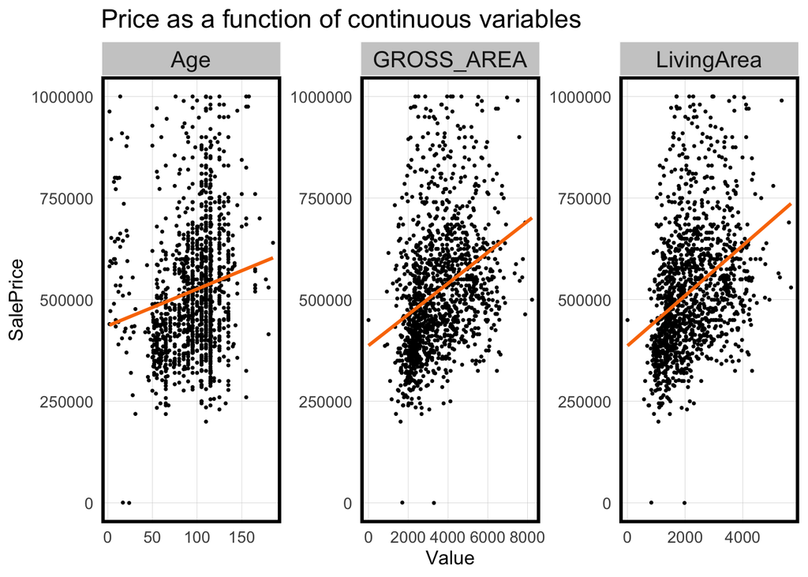

```r
## Home Features cor
st_drop_geometry(boston.sf) %>%
  mutate(Age = 2015 - YR_BUILT) %>%
  dplyr::select(SalePrice, LivingArea, Age, GROSS_AREA) %>%
  filter(SalePrice <= 1000000, Age < 500) %>%
  gather(Variable, Value, -SalePrice) %>%
   ggplot(aes(Value, SalePrice)) +
     geom_point(size = .5) + geom_smooth(method = "lm", se=F, colour = "#FA7800") +
     facet_wrap(~Variable, ncol = 3, scales = "free") +
     labs(title = "Price as a function of continuous variables") +
     plotTheme()
```

Can we resize this somehow to make it look better?

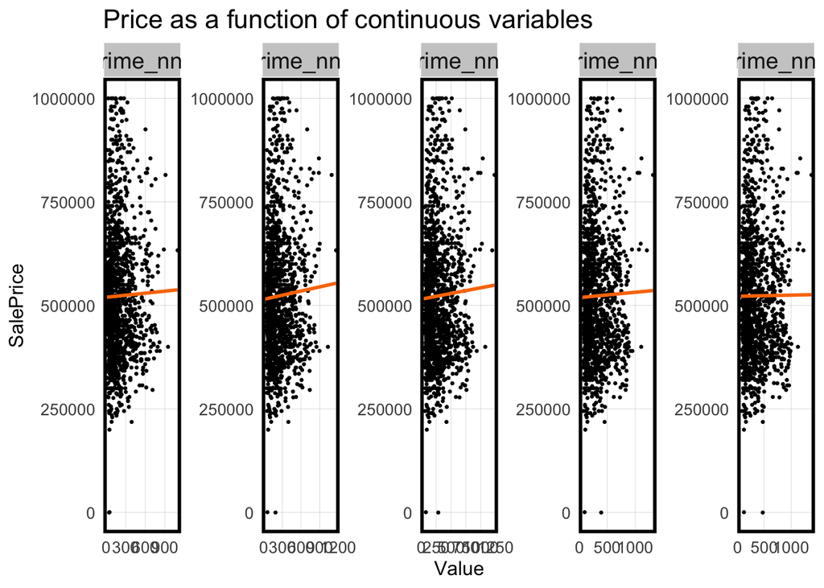

```r
## Crime cor
boston.sf %>%
  st_drop_geometry() %>%
  mutate(Age = 2015 - YR_BUILT) %>%
  dplyr::select(SalePrice, starts_with("crime_")) %>%
  filter(SalePrice <= 1000000) %>%
  gather(Variable, Value, -SalePrice) %>%
   ggplot(aes(Value, SalePrice)) +
     geom_point(size = .5) + geom_smooth(method = "lm", se=F, colour = "#FA7800") +
     facet_wrap(~Variable, nrow = 1, scales = "free") +
     labs(title = "Price as a function of continuous variables") +
     plotTheme()
```

## Correlation matrix

A correlation matrix gives us the pairwise correlation of each set of features in our data. It is usually advisable to include the target/outcome variable in this so we can understand which features are related to it.

Some things to notice in this code; we use `select_if()` to select only the features that are numeric. This is really handy when you don’t want to type or hard-code the names of your features; `ggcorrplot()` is a function from the `ggcorrplot` package.

**Let’s take a few minutes to interpret this**

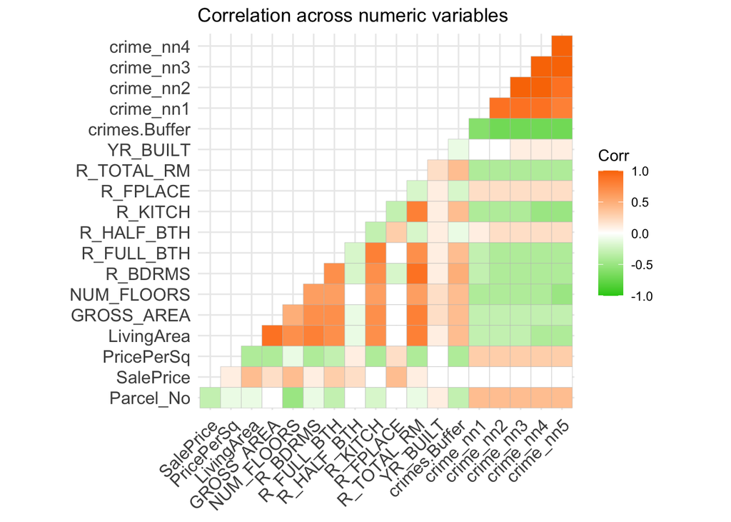

```r
numericVars <-
  select_if(st_drop_geometry(boston.sf), is.numeric) %>% na.omit()

ggcorrplot(
  round(cor(numericVars), 1),
  p.mat = cor_pmat(numericVars),
  colors = c("#25CB10", "white", "#FA7800"),
  type="lower",
  insig = "blank") +
    labs(title = "Correlation across numeric variables")
```

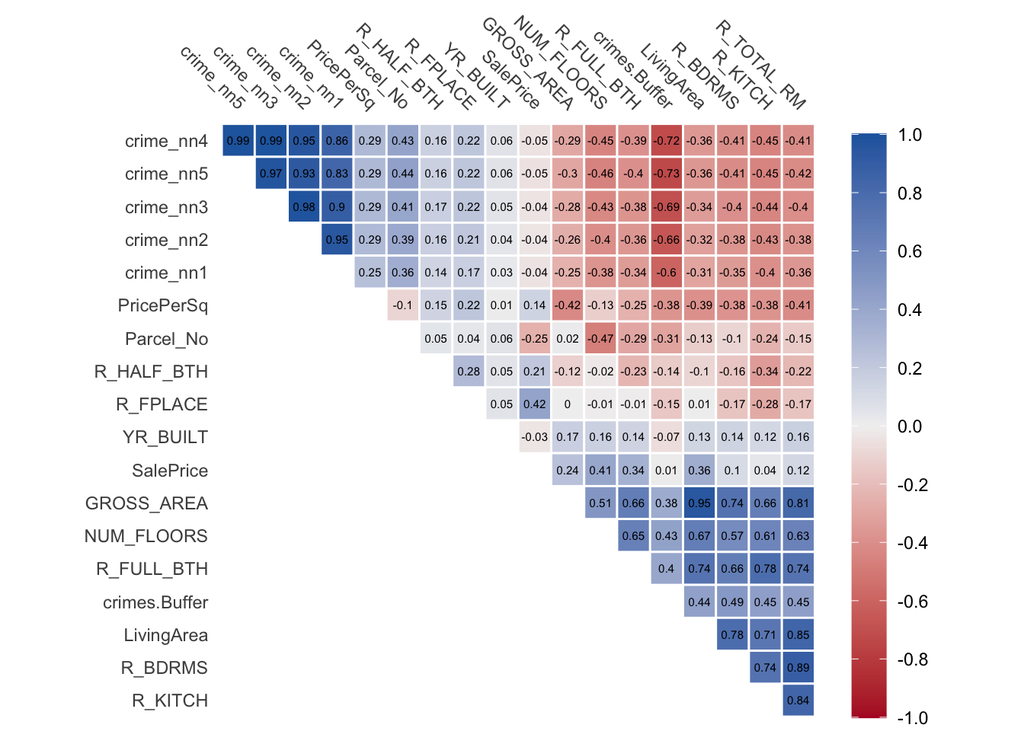

```r
# yet another way to plot the correlation plot using the corrr library
numericVars %>%
  correlate() %>%
  autoplot() +
  geom_text(aes(label = round(r,digits=2)),size = 2)
```

# Univarite correlation -> multi-variate OLS regression

### Pearson’s r - Correlation Coefficient

Pearson’s r Learning links: * [Pearson Correlation Coefficient (r) | Guide & Examples](https://www.scribbr.com/statistics/pearson-correlation-coefficient/) * [Correlation Test Between Two Variables in R](http://www.sthda.com/english/wiki/correlation-test-between-two-variables-in-r)

Note: the use of the `ggscatter()` function from the `ggpubr` package to plot the *Pearson’s rho* or *Pearson’s r* statistic; the Correlation Coefficient. This number can also be squared and represented as `r2`. However, this differs from the `R^2` or `R2` or “R-squared” of a linear model fit, known as the Coefficient of Determination. This is explained a bit more below.

```r
boston_sub_200k <- st_drop_geometry(boston.sf) %>%
filter(SalePrice <= 2000000)

cor.test(boston_sub_200k$LivingArea,
         boston_sub_200k$SalePrice,
         method = "pearson")
```

```
##
##  Pearson's product-moment correlation
##
## data:  boston_sub_200k$LivingArea and boston_sub_200k$SalePrice
## t = 13.415, df = 1447, p-value < 2.2e-16
## alternative hypothesis: true correlation is not equal to 0
## 95 percent confidence interval:
##  0.2859924 0.3776199
## sample estimates:
##       cor
## 0.3325908
```

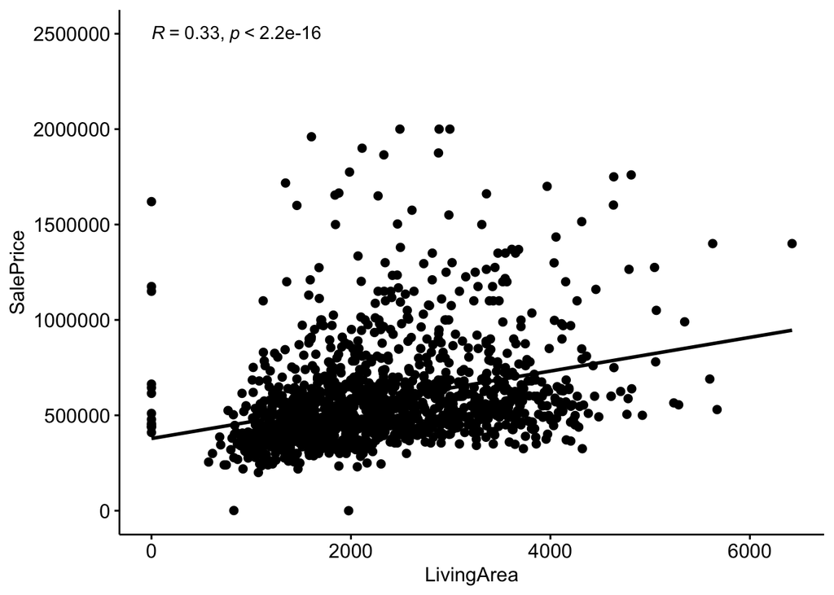

```r
ggscatter(boston_sub_200k,
          x = "LivingArea",
          y = "SalePrice",
          add = "reg.line") +
  stat_cor(label.y = 2500000)
```

The Pearson’s rho - Correlation Coefficient and the R2 Coefficient of Determination are **very** frequently confused! It is a really common mistake, so take a moment to understand what they are and how they differ. [This blog](https://towardsdatascience.com/r%C2%B2-or-r%C2%B2-when-to-use-what-4968eee68ed3) is a good explanation. In summary:

- The `r` is a measure the degree of relationship between two variables say x and y. It can go between -1 and 1. 1 indicates that the two variables are moving in unison.
- However, `R2` shows percentage variation in y which is explained by all the x variables together. Higher the better. It is always between 0 and 1. It can never be negative – since it is a squared value.

## Univarite Regression

### R2 - Coefficient of Determination

Discussed above, the `R^2` or “R-squared” is a common way to validate the predictions of a linear model. Below we run a linear model on our data with the `lm()` function and get the output in our R terminal. At first this is an intimidating amount of information! Here is a [great resource](https://towardsdatascience.com/understanding-linear-regression-output-in-r-7a9cbda948b3) to understand how that output is organized and what it means.

What we are focusing on here is that `R-squared`, `Adjusted R-squared` and the `Coefficients`.

What’s the `R2` good for as a diagnostic of model quality?

Can somebody interpret the coefficient?

Note: Here we use `ggscatter` with the `..rr.label` argument to show the `R2` Coefficient of Determination.

```r
livingReg <- lm(SalePrice ~ LivingArea, data = boston_sub_200k)

summary(livingReg)
```

```
##
## Call:
## lm(formula = SalePrice ~ LivingArea, data = boston_sub_200k)
##
## Residuals:
##     Min      1Q  Median      3Q     Max
## -553037 -143649  -61127   61996 1439918
##
## Coefficients:
##              Estimate Std. Error t value Pr(>|t|)
## (Intercept) 3.784e+05  1.606e+04   23.55   <2e-16 ***
## LivingArea  8.835e+01  6.586e+00   13.41   <2e-16 ***
## ---
## Signif. codes:  0 '***' 0.001 '**' 0.01 '*' 0.05 '.' 0.1 ' ' 1
##
## Residual standard error: 245200 on 1447 degrees of freedom
## Multiple R-squared:  0.1106, Adjusted R-squared:   0.11
## F-statistic:   180 on 1 and 1447 DF,  p-value: < 2.2e-16
```

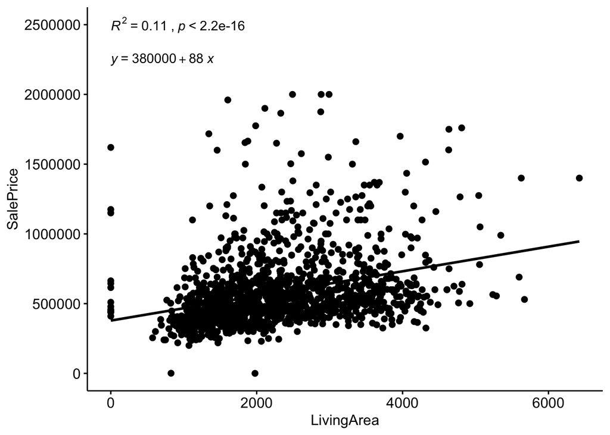

```r
ggscatter(boston_sub_200k,
          x = "LivingArea",
          y = "SalePrice",
          add = "reg.line") +
  stat_cor(aes(label = paste(..rr.label.., ..p.label.., sep = "~`,`~")), label.y = 2500000) +
  stat_regline_equation(label.y = 2250000)
```

## Prediction example

Make a prediction using the coefficient, intercept etc.,

```r
coefficients(livingReg)
```

```
##  (Intercept)   LivingArea
## 378370.01571     88.34939
```

```r
new_LivingArea = 4000

# "by hand"
378370.01571  + 88.34939 * new_LivingArea
```

```
## [1] 731767.6
```

```r
# predict() function
predict(livingReg, newdata = data.frame(LivingArea = 4000))
```

```
##        1
## 731767.6
```

## Multivariate Regression

Let’s take a look at this regression - how are we creating it?

What’s up with these categorical variables?

Better R-squared - does that mean it’s a better model?

```r
reg1 <- lm(SalePrice ~ ., data = boston_sub_200k %>%
                                 dplyr::select(SalePrice, LivingArea, Style,
                                               GROSS_AREA, R_TOTAL_RM, NUM_FLOORS,
                                               R_BDRMS, R_FULL_BTH, R_HALF_BTH,
                                               R_KITCH, R_AC, R_FPLACE))

summary(reg1)
```

```
##
## Call:
## lm(formula = SalePrice ~ ., data = boston_sub_200k %>% dplyr::select(SalePrice,
##     LivingArea, Style, GROSS_AREA, R_TOTAL_RM, NUM_FLOORS, R_BDRMS,
##     R_FULL_BTH, R_HALF_BTH, R_KITCH, R_AC, R_FPLACE))
##
## Residuals:
##     Min      1Q  Median      3Q     Max
## -751502 -114977  -24349   76573 1140906
##
## Coefficients:
##                            Estimate Std. Error t value Pr(>|t|)
## (Intercept)               304321.41   47767.05   6.371 2.53e-10 ***
## LivingArea                   108.96      27.74   3.928 8.97e-05 ***
## StyleCape                 -74027.05   41070.55  -1.802   0.0717 .
## StyleColonial             -74349.20   41382.28  -1.797   0.0726 .
## StyleConventional         -31104.33   44158.08  -0.704   0.4813
## StyleDecker               -28653.61   54355.42  -0.527   0.5982
## StyleDuplex                -3761.19   67004.22  -0.056   0.9552
## StyleRaised\xa0Ranch     -128281.10   57215.75  -2.242   0.0251 *
## StyleRanch                -45789.06   49689.36  -0.922   0.3569
## StyleRow\xa0End            67168.00   53090.42   1.265   0.2060
## StyleRow\xa0Middle        142070.90   53492.89   2.656   0.0080 **
## StyleSemi?Det               7227.63   51174.62   0.141   0.8877
## StyleSplit\xa0Level        19593.93   87370.61   0.224   0.8226
## StyleTri?Level           -185158.48  211958.48  -0.874   0.3825
## StyleTudor                -95804.61  212026.50  -0.452   0.6514
## StyleTwo\xa0Fam\xa0Stack   -4826.54   44316.44  -0.109   0.9133
## StyleUnknown             -519952.10  151179.96  -3.439   0.0006 ***
## StyleVictorian           -124651.25   69902.71  -1.783   0.0748 .
## GROSS_AREA                   -17.98      16.13  -1.115   0.2652
## R_TOTAL_RM                  4910.22    4404.03   1.115   0.2651
## NUM_FLOORS                105306.46   21078.39   4.996 6.58e-07 ***
## R_BDRMS                   -10106.82    5892.67  -1.715   0.0865 .
## R_FULL_BTH                 84902.77   12621.96   6.727 2.51e-11 ***
## R_HALF_BTH                 18707.54   11963.76   1.564   0.1181
## R_KITCH                  -136219.03   17801.70  -7.652 3.63e-14 ***
## R_ACD                     -69287.58  208085.74  -0.333   0.7392
## R_ACN                     -91210.45   18810.32  -4.849 1.38e-06 ***
## R_ACU                     326196.37   66654.38   4.894 1.10e-06 ***
## R_FPLACE                   84021.58    9721.13   8.643  < 2e-16 ***
## ---
## Signif. codes:  0 '***' 0.001 '**' 0.01 '*' 0.05 '.' 0.1 ' ' 1
##
## Residual standard error: 207300 on 1420 degrees of freedom
## Multiple R-squared:  0.3763, Adjusted R-squared:  0.364
## F-statistic:  30.6 on 28 and 1420 DF,  p-value: < 2.2e-16
```

## Marginal Response Plots

Let’s try some of these out. They help you learn more about the relationships in the model.

What does a long line on either side of the blue circle suggest?

What does the location of the blue circle relative to the center line at zero suggest?

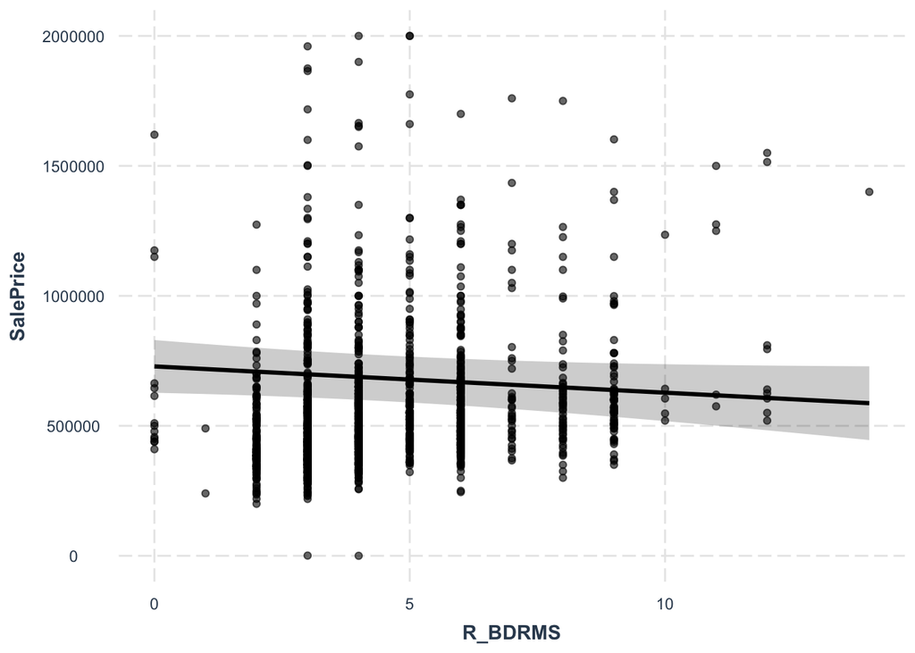

```r
## Plot of marginal response
effect_plot(reg1, pred = R_BDRMS, interval = TRUE, plot.points = TRUE)
```

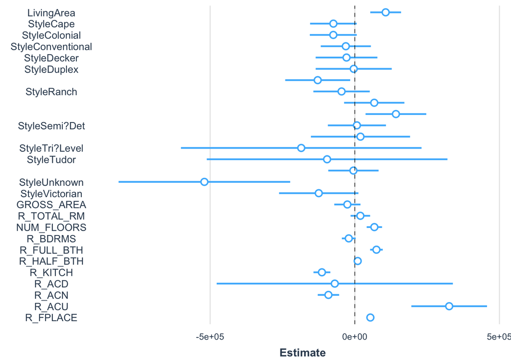

```r
## Plot coefficients
plot_summs(reg1, scale = TRUE)
```

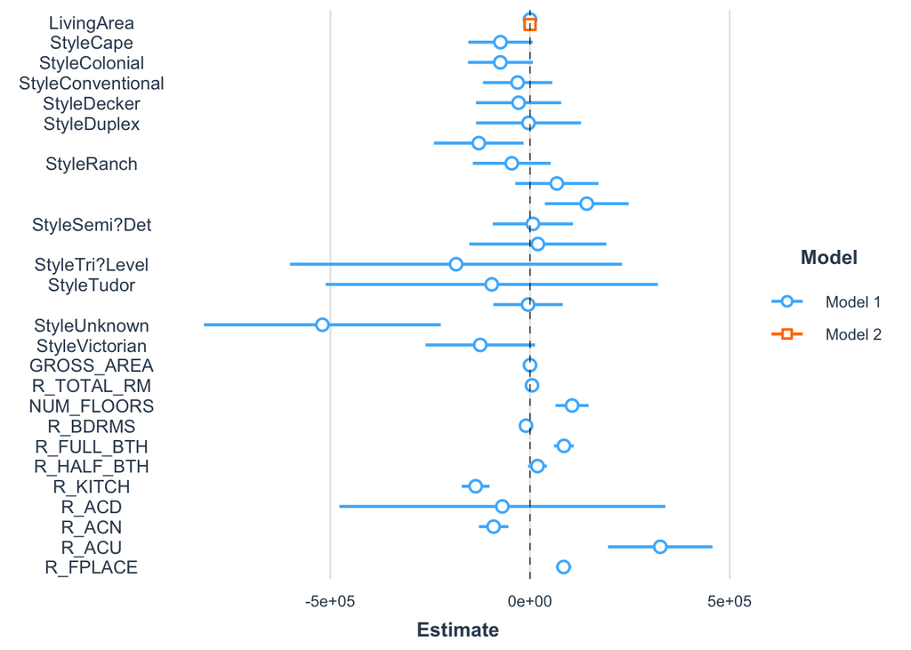

```r
## plot multiple model coeffs
plot_summs(reg1, livingReg)
```

Challenges:

-What is the Coefficient of LivingArea when Average Distance to 2-nearest crimes are considered?

-Build a regression with LivingArea and crime_nn2? Report the regression coefficient for LivingArea. Is it different than it was before? Why?

- Try to engineer a ‘fixed effect’ out of the other variables in an attempt to parameterize a variable that suggests a big or fancy house or levels of fanciness. How does this affect your model?